# Act Report of the WeRateDogs Twitter Analysis

This project is about the WeRateDogs Twitter account which rates people's dogs with a humorous comment about the dogs.

## Most Common Dog Breed

There were different types of dog breeds in the dataset. I had to check for the most common Dog breeds by listing out the top ten. Surprisingly, the **Labrador Retriever** and the **Golden Retriever** were the most common breeds with almost same number of tweets followed by the **Chihuahua** and followed closely by the **Pembroke**. The graph that shows the top 10 is included below.

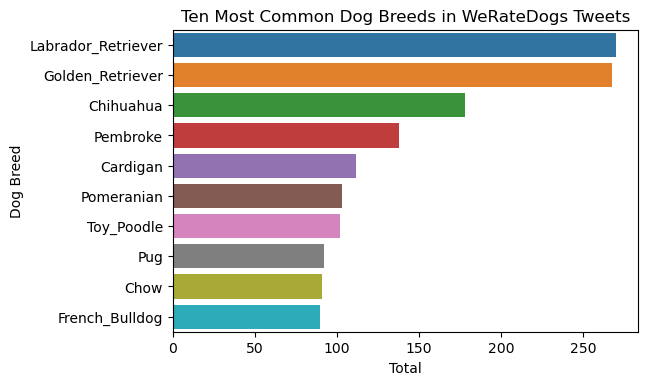

## Most Common Dog Ratings

Apparently, the most common score by far is **12/10** followed by **10/10** and **11/10**. These three score ratings are the onluy ones with more than a thousand counts. The rest are less than 800 counts (like the **13/10, 9/10, 8/10**) It is noteworthy to mention that in the three most common scores does not stray too far from each other, and also the numerator doesn't stray too far above the denominator.

Also, the standard denominator which is **10** is not consistent in the tweets.

12/10 1394

10/10 1273

11/10 1200

13/10 799

9/10 450

8/10 288

7/10 153

14/10 104

5/10 100

6/10 96

3/10 57

4/10 45

2/10 27

1/10 12

144/120 3

88/80 3

11.26/10 3

80/80 3

7/11 3

420/10 3

121/110 3

44/40 3

60/50 3

45/50 3

1776/10 3

99/90 3

50/50 3

4/20 3

204/170 3

9/11 3

165/150 3

9.75/10 3

24/7 3

84/70 3

0/10 3

13.5/10 3

11.27/10 3

1/2 3

Name: score_comb, dtype: int64

## Total Tweets per Month

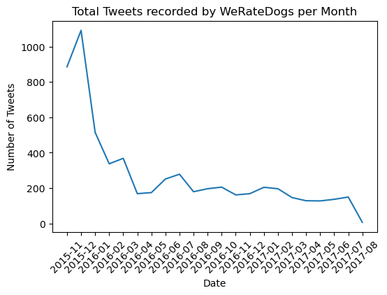